# Dietary Kinetics of a PFAS Mixture in American Toads (*Anaxyrus americanus*)

Andrew East

2023-09-07

# Methods

## Experimental Design

The study was designed to capture toxico/phamacokinetics of dietary exposure to a PFAS mixture.

A contaminated diet was fed to all animals for 28 days and then all animals were fed a control diet for 28 days.

Day 28 is concurrently a datapoint for both study periods.

Tarazona (2015 and 2016) as well as OECD TG #305 were used as guides, but this study design is common for establishment of repeat dose dietary uptake and elimination parameters.

## Worms

Worms were grown in two soils: one soil that was control soil and one soil that was spiked with 16 PFAS at 0.1 mg/kg.

Worms were grown in these soils for 28 days, collected, rinsed, then homogenized into a “control” and “PFAS” slurry based on their group.

A standard curve of worm slurry mass to worm slurry volume and related back to the average worm weight to develop a slurry volume to single worm rate.

## Toads

Toads were obtained from a supplier that collected them in the field.

12 toads were sampled on day 0 for background and then 6 toads sampled weekly through the remainder of the study duration.

# Samples and Analytical Chemistry

Blood, liver, and the remainder of the animal were collected and analysed for PFAS concentration.

The remainder of the animal is termed “Whole Body” for brevity but excludes blood and liver.

# Analysis

## Package Management

Notable `r` packages are related to robust nonlinear least squares parameterization, differential equation solving and parameterization.

R version is R version 4.3.1 (2023-06-16 ucrt) and markdown document compiled on 2023-10-11.

```r
### install_load function from maloneypatr, Irucka Embry, USGS and stack overflow

### see https://gitlab.com/iembry/install.load

### Check if R package is installed then load library answered by

###        maloneypatr is the source for the original function. See http://stackoverflow.com/questions/15155814/check-if-r-package-is-installed-then-load-library

install_load <- function (package1, ...) {

  # convert arguments to vector

  packages <- c(package1, ...)

  # start loop to determine if each package is installed

  for (package in packages) {

    # if package is installed locally, load

  if (package %in% rownames(installed.packages()))

      try(do.call(library, list(package))) # Source 2

    # if package is not installed locally, download and then load

    else {

      install.packages(package, repos =

        c("https://cloud.r-project.org"),

        dependencies = NA, type = getOption("pkgType"))

      try(do.call(library, list(package))) # Source 2

    }

  }

}



install_load("knitr", "readxl","tidyverse","deSolve","minpack.lm","FME","ggpubr", "nlstools", "investr","propagate",  "mgcv", "mosaicCalc", "rbioacc")





###! Tread Carefully Here !##

options(dplyr.summarise.inform=F)

### This turns off the tidyverse summarize/summarise messages indicating default grouping patterns in resultant tibbles ##

### If you don't know what this means, check out https://stackoverflow.com/questions/62140483/how-to-interpret-dplyr-message-summarise-regrouping-output-by-x-override

### Implications of this being false are unknown errors and impacts in other activities in this R session!
```

## Data

Data are imported as stacked and filtered to just PFOS and 8:2 FTS from the original data.

Columns in initial dataframe identify each sample by toad ID#, timepoint (redundant to toad ID# technically), PFAS, and tissue.

Data created are two concentration vectors that (1) set Day 0 concentrations of 0 equal to 0.1 and other days’ concentrations of 0 to NA and (2) set all concentrations of 0 to 0.1.

Notably, the concentrations set to 0 are not correctly accounting for the limits of quantification of the analytical method and need to be replaced with the appropriate value (e.g. 1/2 limit of detection) as to not bias the estimation of parameters.

Summary data frames are also created (1) from concentrations including 0 and (2) from concentrations adjusted to a lower limit of 0.1.

```r
toad <- read_csv("toad_stacked_data_subset_East_07SEP2023.csv",show_col_types=F)



toad$PFAS <- factor(toad$PFAS)

toad$tissue <- factor(toad$tissue, levels=c("liver","wholebody"),labels=c("Liver","Whole Body"))



toad <- toad |>

  mutate(conc2=case_when(

    concentration_ug_per_kg==0&day==0~0.1,

    concentration_ug_per_kg==0&day>=1~as.numeric(NA),

    T~concentration_ug_per_kg

  ),

  conc3=case_when(

    concentration_ug_per_kg==0~0.1,

    T~concentration_ug_per_kg

  ))



toad <- toad |>

  mutate(depday=day-28)



toadsumm <- toad |>

  group_by(PFAS, tissue, day) |>

  summarize(

    count=sum(!is.na(concentration_ug_per_kg)),

    mean=mean(concentration_ug_per_kg, na.rm=T),

    median=median(concentration_ug_per_kg, na.rm=T),

    sd=sd(concentration_ug_per_kg, na.rm=T),

    sem=sd/sqrt(count),

    perc_cv=(sd/mean)*100,

    upper=quantile(concentration_ug_per_kg, probs=c(0.975), names=F, na.rm=T),

    lower=quantile(concentration_ug_per_kg, probs=c(0.025), names=F, na.rm=T),

  )



toadsumm3 <- toad |>

  group_by(PFAS, tissue, day) |>

  summarize(

    count=sum(!is.na(conc3)),

    mean=mean(conc3, na.rm=T),

    median=median(conc3, na.rm=T),

    sd=sd(conc3, na.rm=T),

    sem=sd/sqrt(count),

    perc_cv=(sd/mean)*100,

    upper=quantile(conc3, probs=c(0.975), names=F, na.rm=T),

    lower=quantile(conc3, probs=c(0.025), names=F, na.rm=T),

  )
```

## Figure 1

Data for each PFAS and tissue fitted with generalized additive model (cubic spline, 5 knots, NAs omitted) on log scaled y-axis indicate there are PFAS and tissue specific patterns.

The difference in uptake and elimination rates between PFOS and 8:2 FTS are to be expected as well as the higher concentrations in the liver tissues.

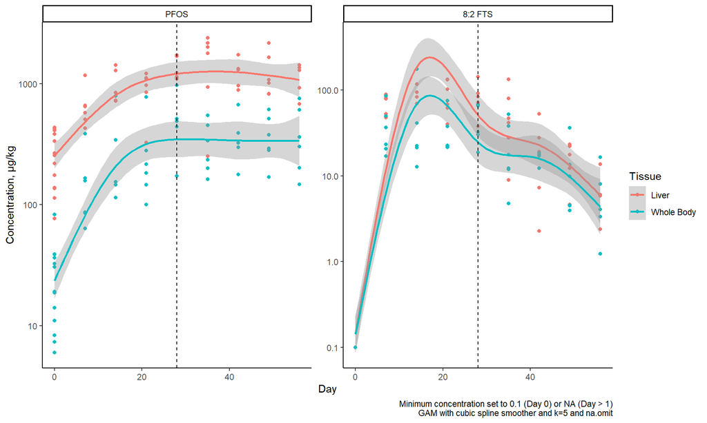

```r
#ggplot(toad, aes(x=day, y=conc2, color=tissue)) +

#  geom_point() +

#  geom_smooth(method="loess", formula=y~x, se=F, span=0.75) +

#  geom_vline(xintercept=28, linetype="dashed") +

#  facet_wrap(~fct_reorder(PFAS,concentration_ug_per_kg, .fun=median, .desc=T), scales="free_y") +

#  theme_classic() +

#  labs(x="Day",y="Concentration, \u03BCg/kg, minimum set to 0.1 (Day 0) or NA (Day > 1)",color="Tissue") +

#  scale_y_log10()





ggplot(toad, aes(x=day, y=conc2, color=tissue)) +

  geom_point() +

  geom_smooth(method="gam", formula=y~s(x, bs="cs", k=5), se=T, method.args=list(na.action="na.omit")) +

  geom_vline(xintercept=28, linetype="dashed") +

  facet_wrap(~fct_reorder(PFAS,concentration_ug_per_kg, .fun=median, .desc=T), scales="free_y") +

  theme_classic() +

    labs(x="Day",y="Concentration, \u03BCg/kg",color="Tissue", caption="Minimum concentration set to 0.1 (Day 0) or NA (Day > 1)\nGAM with cubic spline smoother and k=5 and na.omit") +

  scale_y_log10()
```

## Figure 2

This figure, similar to above, includes the lower limit set to 0.1 and indicates it has little effect except in some later 8:2 FTS samples.

The presence of non-detect samples after a period of elimination is not surprising for 8:2 FTS given the elevated uptake and elimination rate parameters.

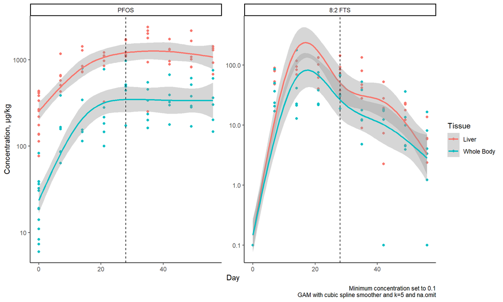

```r
#ggplot(toad, aes(x=day, y=conc3, color=tissue)) +

#  geom_point() +

#  geom_smooth(method="loess",formula=y~x, se=F, span=0.75) +

#  geom_vline(xintercept=28, linetype="dashed") +

#  facet_wrap(~fct_reorder(PFAS,concentration_ug_per_kg, .fun=median, .desc=T), scales="free_y") +

#  theme_classic() +

#  labs(x="Day",y="Concentration, \u03BCg/kg, minimum set to 0.1",color="Tissue") +

#  scale_y_log10()





ggplot(toad, aes(x=day, y=conc3, color=tissue)) +

  geom_point() +

  geom_smooth(method="gam", formula=y~s(x, bs="cs", k=5), se=T, method.args=list(na.action="na.omit")) +

  geom_vline(xintercept=28, linetype="dashed") +

  facet_wrap(~fct_reorder(PFAS,concentration_ug_per_kg, .fun=median, .desc=T), scales="free_y") +

  theme_classic() +

  labs(x="Day",y="Concentration, \u03BCg/kg",color="Tissue", caption="Minimum concentration set to 0.1\nGAM with cubic spline smoother and k=5 and na.omit") +

  scale_y_log10()
```

## Figure 3

This figure includes the original (nonsensical) lower limit of 0 with untransformed y-axis.

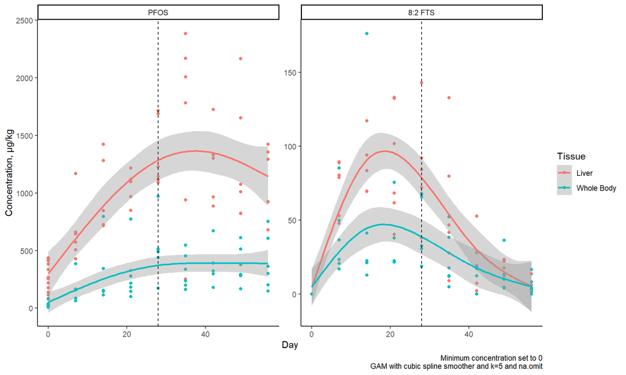

```r
ggplot(toad, aes(x=day, y=concentration_ug_per_kg, color=tissue)) +

  geom_point() +

  geom_smooth(method="gam", formula=y~s(x, k=5, bs="cs"), se=T, method.args=list(na.action="na.omit")) +

  geom_vline(xintercept=28, linetype="dashed") +

  facet_wrap(~fct_reorder(PFAS,concentration_ug_per_kg, .fun=median, .desc=T), scales="free_y") +

  theme_classic() +

  labs(x="Day",y="Concentration, \u03BCg/kg",color="Tissue", caption="Minimum concentration set to 0\nGAM with cubic spline smoother and k=5 and na.omit")
```

## Figure 3b

This figure shows matched y-axes to indicate the difference in overall uptake between the PFAS.

Importantly, the tissue concentrations are at least one order of magnitude apart while the worm concentrations of each PFAS were nearly identical concentrations.

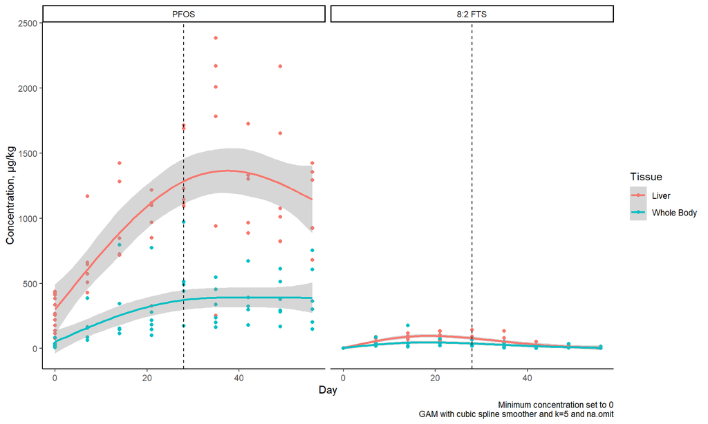

```r
ggplot(toad, aes(x=day, y=concentration_ug_per_kg, color=tissue)) +

  geom_point() +

  geom_smooth(method="gam", formula=y~s(x, k=5, bs="cs"), se=T, method.args=list(na.action="na.omit")) +

  geom_vline(xintercept=28, linetype="dashed") +

  facet_wrap(~fct_reorder(PFAS,concentration_ug_per_kg, .fun=median, .desc=T)) +

  theme_classic() +

  labs(x="Day",y="Concentration, \u03BCg/kg",color="Tissue", caption="Minimum concentration set to 0\nGAM with cubic spline smoother and k=5 and na.omit")
```

## Figure 4

Some details emerge from viewing the center+dispersion summaries–peak PFOS concentrations in liver occur during elimination period and peak liver 8:2 FTS concentrations are during uptake.

Additionally, in both PFAS, the peak wholebody concentrations were on day 28 or prior depending on the statistic.

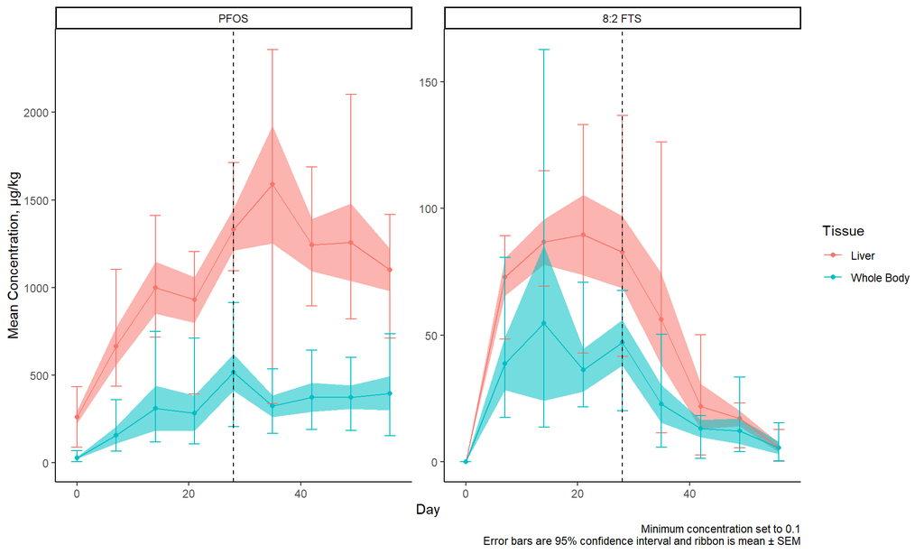

```r
ggplot() +

  geom_ribbon(data=toadsumm3, aes(x=day, ymin=mean-sem, ymax=mean+sem, linetype='blank', fill=tissue, alpha=0.05), show.legend=F) +

  geom_point(data=toadsumm3, aes(x=day, y=mean, color=tissue)) +

  geom_line(data=toadsumm3, aes(x=day, y=mean, color=tissue)) +

  geom_errorbar(data=toadsumm3, aes(ymin=lower, ymax=upper, x=day, color=tissue), width=2) +

  geom_vline(xintercept=28, linetype="dashed") +

 facet_wrap(~fct_reorder(PFAS,mean, .desc=T), scales="free_y") +

  theme_classic()+

  labs(x="Day",y="Mean Concentration, \u03BCg/kg",color="Tissue", caption="Minimum concentration set to 0.1\nError bars are 95% confidence interval and ribbon is mean \u00B1 SEM")
```

## Figure 4b

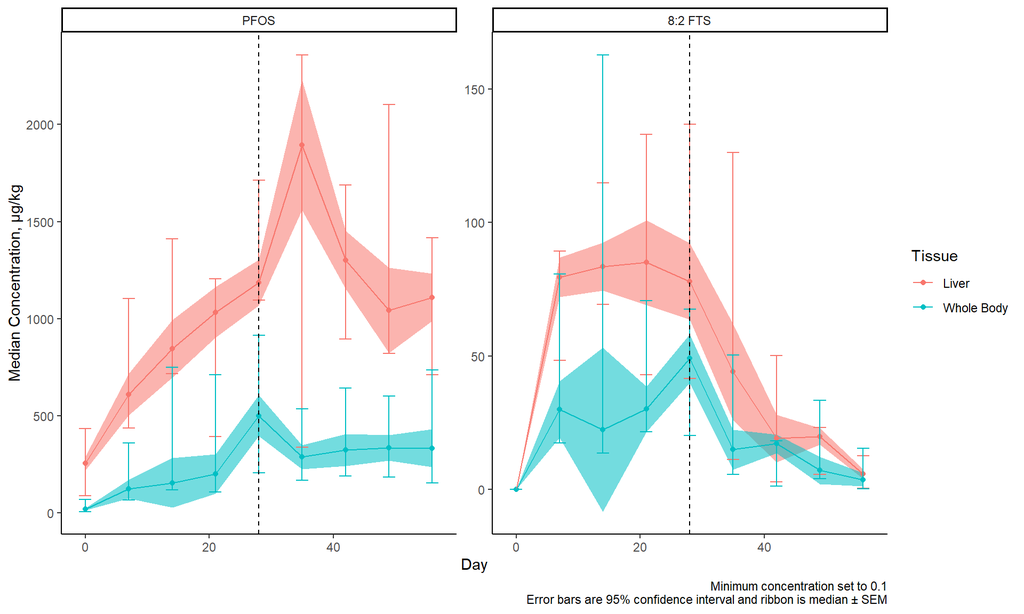

```r
ggplot() +

  geom_ribbon(data=toadsumm3, aes(x=day, ymin=median-sem, ymax=median+sem, linetype='blank', fill=tissue, alpha=0.05), show.legend=F) +

  geom_point(data=toadsumm3, aes(x=day, y=median, color=tissue)) +

  geom_line(data=toadsumm3, aes(x=day, y=median, color=tissue)) +

  geom_errorbar(data=toadsumm3, aes(ymin=lower, ymax=upper, x=day, color=tissue), width=2) +

  geom_vline(xintercept=28, linetype="dashed") +

  facet_wrap(~fct_reorder(PFAS,mean, .desc=T), scales="free_y") +

  theme_classic()+

  labs(x="Day",y="Median Concentration, \u03BCg/kg",color="Tissue", caption="Minimum concentration set to 0.1\nError bars are 95% confidence interval and ribbon is median \u00B1 SEM")
```

## Prediction Strategy

General description is to minimally use the strategies of OECD TG #305 for dietary bioaccumulation in fish. In this case, uptake and elimination rates can be estimated with linear regressions which provide (1) an estimate of rates, (2) evaluation of single vs multiple uptake/elimination processes, and (3) starting parameters for nonlinear or dynamic techniques.

### Liver elimination via ln(concentration)~time

OECD TG #305 (among other sources) relies on natural log concentration by elimination time (i.e. no exposure, control diet) linear regression to determine a slope to estimate a single process exponential decay type elimination parameter.

The linearity of the relationship is useful in evaluating the question of whether there is one elimination process or others.

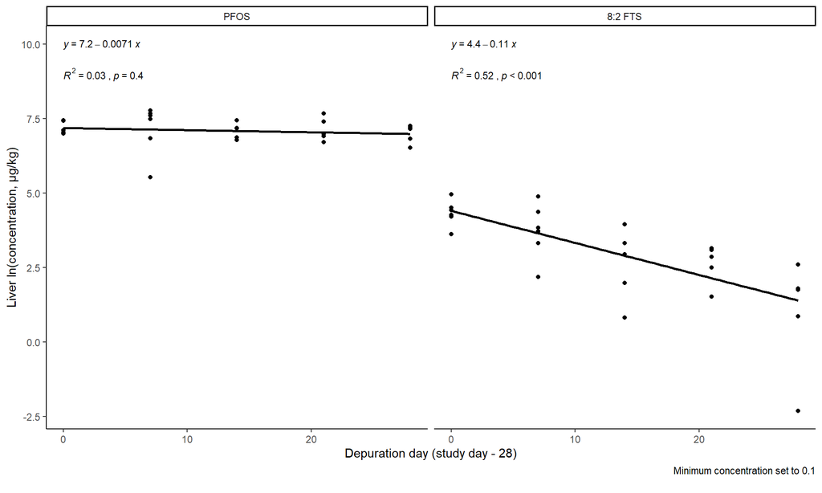

```r
ggplot(data = toad%>%filter(day%in%c(28:56)&tissue=="Liver"), aes(x = depday, y = log(conc3))) +

  stat_smooth(method = "lm", se=FALSE, color="black", formula = y ~ x) +

  geom_point() +

  stat_cor(aes(label = paste(after_stat(rr.label), after_stat(p.label), sep = "~`,`~")),

           r.accuracy = 0.01,

           p.accuracy = 0.001,

           label.x = 0, label.y = 9, size = 3) +

  stat_regline_equation(aes(label = after_stat(eq.label)),

                        label.x = 0, label.y = 10, size = 3) +

  theme_classic() +

  facet_wrap(~fct_reorder(PFAS,log(conc3), .fun=median, .desc=T)) +

  labs(y="Liver ln(concentration, \u03BCg/kg)", x="Depuration day (study day - 28)", caption="Minimum concentration set to 0.1\n")
```

#### PFOS elimination

“depday” is “depuration day” as in (study day - 28) or the length of time eating control diet post-exposure period.

Lack of significance on slope p-value is worthy of note, but the small magnitude of is expected.

```r
summary(lm(log(conc3)~depday, data = toad%>%filter(day%in%c(28:56)&tissue=="Liver"&PFAS=="PFOS")))
```

```
##
## Call:
## lm(formula = log(conc3) ~ depday, data = toad %>% filter(day %in%
##     c(28:56) & tissue == "Liver" & PFAS == "PFOS"))
##
## Residuals:
##      Min       1Q   Median       3Q      Max
## -1.61170 -0.19382 -0.06289  0.26809  0.63737
##
## Coefficients:
##              Estimate Std. Error t value Pr(>|t|)
## (Intercept)  7.191576   0.142562  50.445   <2e-16 ***
## depday      -0.007062   0.008267  -0.854      0.4
## ---
## Signif. codes:  0 '***' 0.001 '**' 0.01 '*' 0.05 '.' 0.1 ' ' 1
##
## Residual standard error: 0.4483 on 27 degrees of freedom
## Multiple R-squared:  0.02632,    Adjusted R-squared:  -0.009746
## F-statistic: 0.7297 on 1 and 27 DF,  p-value: 0.4005
```

#### 8:2 FTS elimination

```r
summary(lm(log(conc3)~depday, data = toad%>%filter(day%in%c(28:56)&tissue=="Liver"&PFAS=="8:2 FTS")))
```

```
##
## Call:
## lm(formula = log(conc3) ~ depday, data = toad %>% filter(day %in%
##     c(28:56) & tissue == "Liver" & PFAS == "8:2 FTS"))
##
## Residuals:
##     Min      1Q  Median      3Q     Max
## -3.7015 -0.3323  0.1862  0.7194  1.2319
##
## Coefficients:
##             Estimate Std. Error t value Pr(>|t|)
## (Intercept)  4.41065    0.34372  12.832 5.27e-13 ***
## depday      -0.10756    0.01993  -5.396 1.05e-05 ***
## ---
## Signif. codes:  0 '***' 0.001 '**' 0.01 '*' 0.05 '.' 0.1 ' ' 1
##
## Residual standard error: 1.081 on 27 degrees of freedom
## Multiple R-squared:  0.5189, Adjusted R-squared:  0.5011
## F-statistic: 29.12 on 1 and 27 DF,  p-value: 1.052e-05
```

### Whole Body elimination via ln(concentration)~time

OECD TG #305 (among other sources) relies on natural log concentration by elimination time (i.e. no exposure, control diet) linear regression to determine a slope to estimate a single process exponential decay type elimination parameter.

The linearity of the relationship is useful in evaluating the question of whether there is one elimination process or others.

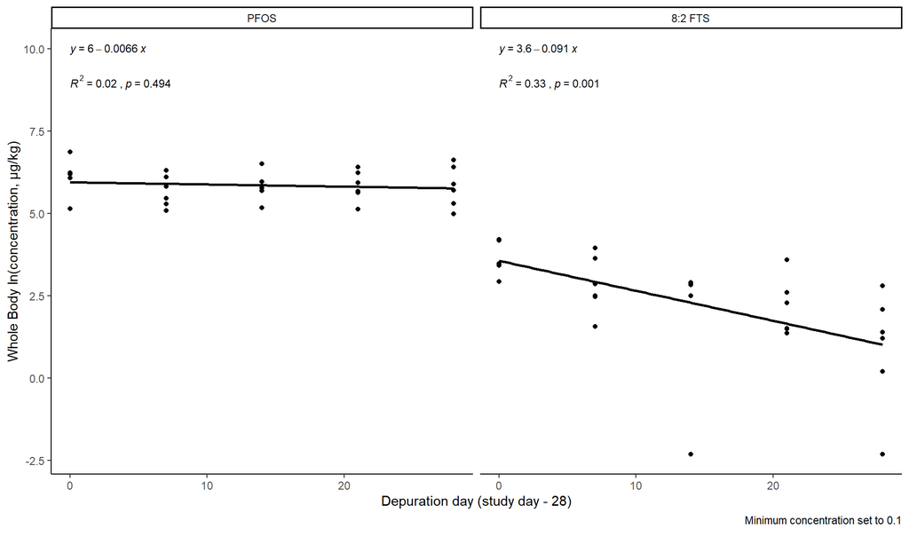

```r
ggplot(data = toad%>%filter(day%in%c(28:56)&tissue=="Whole Body"), aes(x = depday, y = log(conc3))) +

  stat_smooth(method = "lm", se=FALSE, color="black", formula = y ~ x) +

  geom_point() +

  stat_cor(aes(label = paste(after_stat(rr.label), after_stat(p.label), sep = "~`,`~")),

           r.accuracy = 0.01,

          p.accuracy = 0.001,

           label.x = 0, label.y = 9, size = 3) +

  stat_regline_equation(aes(label = after_stat(eq.label)),

                        label.x = 0, label.y = 10, size = 3) +

  theme_classic() +

  facet_wrap(~fct_reorder(PFAS,log(conc3), .fun=median, .desc=T)) +

  labs(y="Whole Body ln(concentration, \u03BCg/kg)", x="Depuration day (study day - 28)", caption="Minimum concentration set to 0.1\n")
```

#### PFOS elimination

“depday” is “depuration day” as in (study day - 28) or the length of time eating control diet post-exposure period.

Lack of significance on slope p-value is worthy of note, but the small magnitude of is expected.

```r
summary(lm(log(conc3)~depday, data = toad%>%filter(day%in%c(28:56)&tissue=="Whole Body"&PFAS=="PFOS")))
```

```
##
## Call:
## lm(formula = log(conc3) ~ depday, data = toad %>% filter(day %in%
##     c(28:56) & tissue == "Whole Body" & PFAS == "PFOS"))
##
## Residuals:
##     Min      1Q  Median      3Q     Max
## -0.8175 -0.4475  0.1087  0.2874  0.9244
##
## Coefficients:
##              Estimate Std. Error t value Pr(>|t|)
## (Intercept)  5.954536   0.163812  36.350   <2e-16 ***
## depday      -0.006588   0.009499  -0.693    0.494
## ---
## Signif. codes:  0 '***' 0.001 '**' 0.01 '*' 0.05 '.' 0.1 ' ' 1
##
## Residual standard error: 0.5151 on 27 degrees of freedom
## Multiple R-squared:  0.0175, Adjusted R-squared:  -0.01889
## F-statistic: 0.4809 on 1 and 27 DF,  p-value: 0.4939
```

#### 8:2 FTS elimination

```r
summary(lm(log(conc3)~depday, data = toad%>%filter(day%in%c(28:56)&tissue=="Whole Body"&PFAS=="8:2 FTS")))
```

```
##
## Call:
## lm(formula = log(conc3) ~ depday, data = toad %>% filter(day %in%
##     c(28:56) & tissue == "Whole Body" & PFAS == "8:2 FTS"))
##
## Residuals:
##     Min      1Q  Median      3Q     Max
## -4.5982 -0.2875  0.2156  0.6383  1.9326
##
## Coefficients:
##             Estimate Std. Error t value Pr(>|t|)
## (Intercept)  3.56939    0.42845   8.331 6.11e-09 ***
## depday      -0.09099    0.02485  -3.662  0.00107 **
## ---
## Signif. codes:  0 '***' 0.001 '**' 0.01 '*' 0.05 '.' 0.1 ' ' 1
##
## Residual standard error: 1.347 on 27 degrees of freedom
## Multiple R-squared:  0.3319, Adjusted R-squared:  0.3071
## F-statistic: 13.41 on 1 and 27 DF,  p-value: 0.001074
```

### Liver uptake via ln(concentration)~time

This analysis is fraught as concentration in tissues is f(uptake and elimination) during uptake period.

OECD TG #305 indicates reliance on this method during “linear” portion of uptake as elimination process(es) may require activation (among others) and would inherently lag uptake.

In this case, this means estimating uptake via linear regression only between days 0 and 7.

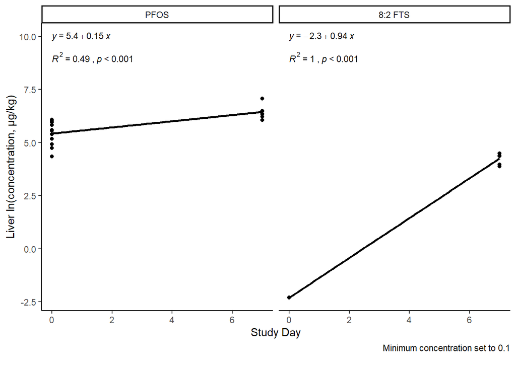

```r
ggplot(data = toad%>%filter(day%in%c(0:7)&tissue=="Liver"), aes(x = day, y = log(conc3))) +

  stat_smooth(method = "lm", se=FALSE, color="black", formula = y ~ x) +

  geom_point() +

  stat_cor(aes(label = paste(after_stat(rr.label), after_stat(p.label), sep = "~`,`~")),

           r.accuracy = 0.01,

           p.accuracy = 0.001,

           label.x = 0, label.y = 9, size = 3) +

  stat_regline_equation(aes(label = after_stat(eq.label)),

                        label.x = 0, label.y = 10, size = 3) +

  theme_classic() +

  facet_wrap(~fct_reorder(PFAS,log(conc3), .fun=median, .desc=T)) +

  labs(y="Liver ln(concentration, \u03BCg/kg)", x="Study Day", caption="Minimum concentration set to 0.1\n")
```

#### PFOS uptake

```r
summary(lm(log(conc3)~day, data = toad%>%filter(day%in%c(0:7)&tissue=="Liver"&PFAS=="PFOS")))
```

```
##
## Call:
## lm(formula = log(conc3) ~ day, data = toad %>% filter(day %in%
##     c(0:7) & tissue == "Liver" & PFAS == "PFOS"))
##
## Residuals:
##      Min       1Q   Median       3Q      Max
## -1.08188 -0.32150  0.02823  0.45836  0.65122
##
## Coefficients:
##             Estimate Std. Error t value Pr(>|t|)
## (Intercept)  5.42543    0.14213  38.173  < 2e-16 ***
## day          0.14552    0.03613   4.028 0.000874 ***
## ---
## Signif. codes:  0 '***' 0.001 '**' 0.01 '*' 0.05 '.' 0.1 ' ' 1
##
## Residual standard error: 0.5124 on 17 degrees of freedom
## Multiple R-squared:  0.4883, Adjusted R-squared:  0.4582
## F-statistic: 16.22 on 1 and 17 DF,  p-value: 0.0008735
```

#### 8:2 FTS uptake

```r
summary(lm(log(conc3)~day, data = toad%>%filter(day%in%c(0:7)&tissue=="Liver"&PFAS=="8:2 FTS")))
```

```
##
## Call:
## lm(formula = log(conc3) ~ day, data = toad %>% filter(day %in%
##     c(0:7) & tissue == "Liver" & PFAS == "8:2 FTS"))
##
## Residuals:
##     Min      1Q  Median      3Q     Max
## -0.3944  0.0000  0.0000  0.0000  0.2319
##
## Coefficients:
##             Estimate Std. Error t value Pr(>|t|)
## (Intercept) -2.30259    0.04105  -56.09   <2e-16 ***
## day          0.93772    0.01044   89.86   <2e-16 ***
## ---
## Signif. codes:  0 '***' 0.001 '**' 0.01 '*' 0.05 '.' 0.1 ' ' 1
##
## Residual standard error: 0.148 on 17 degrees of freedom
## Multiple R-squared:  0.9979, Adjusted R-squared:  0.9978
## F-statistic:  8074 on 1 and 17 DF,  p-value: < 2.2e-16
```

### Whole body uptake via ln(concentration)~time

This analysis is fraught as concentration in tissues is f(uptake and elimination) during uptake period.

OECD TG #305 indicates reliance on this method during “linear” portion of uptake as elimination process(es) may require activation (among others) and would inherently lag uptake.

In this case, this means estimating uptake via linear regression only between days 0 and 7.

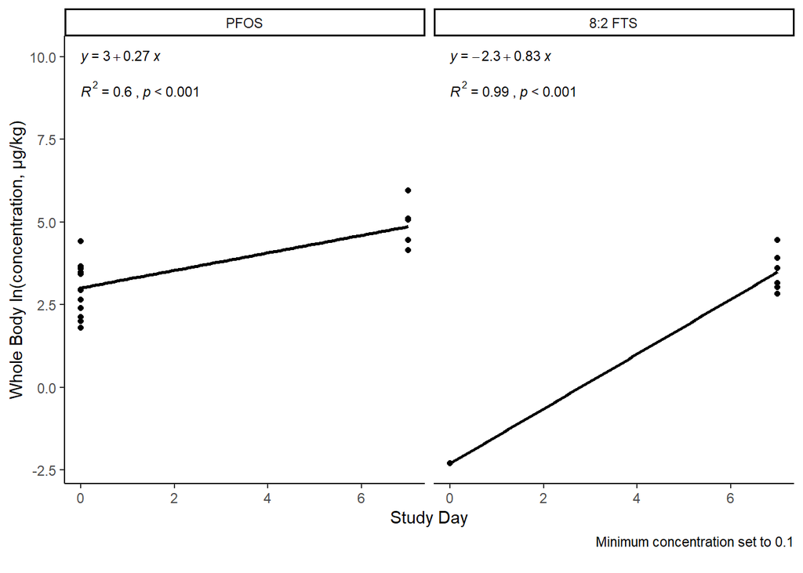

```r
ggplot(data = toad%>%filter(day%in%c(0:7)&tissue=="Whole Body"), aes(x = day, y = log(conc3))) +

  stat_smooth(method = "lm", se=FALSE, color="black", formula = y ~ x) +

  geom_point() +

  stat_cor(aes(label = paste(after_stat(rr.label), after_stat(p.label), sep = "~`,`~")),

           r.accuracy = 0.01,

           p.accuracy = 0.001,

           label.x = 0, label.y = 9, size = 3) +

  stat_regline_equation(aes(label = after_stat(eq.label)),

                        label.x = 0, label.y = 10, size = 3) +

  theme_classic() +

  facet_wrap(~fct_reorder(PFAS,log(conc3), .fun=median, .desc=T)) +

  labs(y="Whole Body ln(concentration, \u03BCg/kg)", x="Study Day", caption="Minimum concentration set to 0.1\n")
```

#### PFOS uptake

```r
summary(lm(log(conc3)~day, data = toad%>%filter(day%in%c(0:7)&tissue=="Whole Body"&PFAS=="PFOS")))
```

```
##
## Call:
## lm(formula = log(conc3) ~ day, data = toad %>% filter(day %in%
##     c(0:7) & tissue == "Whole Body" & PFAS == "PFOS"))
##
## Residuals:
##      Min       1Q   Median       3Q      Max
## -1.21137 -0.51044 -0.05291  0.52926  1.41372
##
## Coefficients:
##             Estimate Std. Error t value Pr(>|t|)
## (Intercept)  3.00704    0.20747   14.49 5.33e-11 ***
## day          0.26532    0.05274    5.03 0.000103 ***
## ---
## Signif. codes:  0 '***' 0.001 '**' 0.01 '*' 0.05 '.' 0.1 ' ' 1
##
## Residual standard error: 0.748 on 17 degrees of freedom
## Multiple R-squared:  0.5982, Adjusted R-squared:  0.5745
## F-statistic: 25.31 on 1 and 17 DF,  p-value: 0.0001028
```

#### 8:2 FTS uptake

```r
summary(lm(log(conc3)~day, data = toad%>%filter(day%in%c(0:7)&tissue=="Whole Body"&PFAS=="8:2 FTS")))
```

```
##
## Call:
## lm(formula = log(conc3) ~ day, data = toad %>% filter(day %in%
##     c(0:7) & tissue == "Whole Body" & PFAS == "8:2 FTS"))
##
## Residuals:
##     Min      1Q  Median      3Q     Max
## -0.6633  0.0000  0.0000  0.0000  0.9501
##
## Coefficients:
##             Estimate Std. Error t value Pr(>|t|)
## (Intercept) -2.30259    0.09174  -25.10  7.1e-15 ***
## day          0.82811    0.02332   35.51  < 2e-16 ***
## ---
## Signif. codes:  0 '***' 0.001 '**' 0.01 '*' 0.05 '.' 0.1 ' ' 1
##
## Residual standard error: 0.3308 on 17 degrees of freedom
## Multiple R-squared:  0.9867, Adjusted R-squared:  0.9859
## F-statistic:  1261 on 1 and 17 DF,  p-value: < 2.2e-16
```

### Liver uptake across days 0:28 for comparative example

Very clearly lacking linearity and inclusion of multiple processes is impactful.

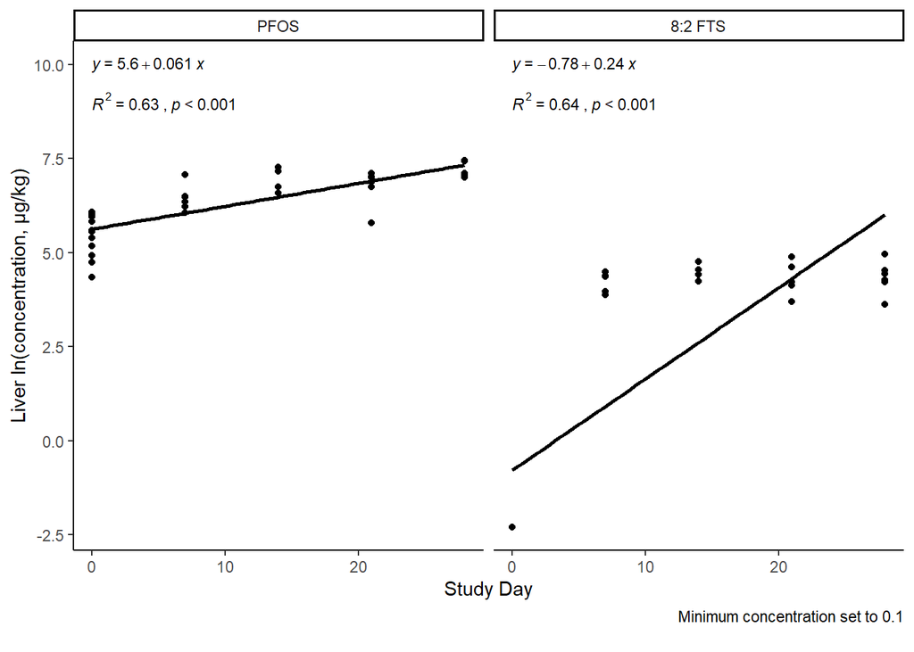

```r
ggplot(data = toad%>%filter(day%in%c(0:28)&tissue=="Liver"), aes(x = day, y = log(conc3))) +

  stat_smooth(method = "lm", se=FALSE, color="black", formula = y ~ x) +

  geom_point() +

  stat_cor(aes(label = paste(after_stat(rr.label), after_stat(p.label), sep = "~`,`~")),

           r.accuracy = 0.01,

           p.accuracy = 0.001,

           label.x = 0, label.y = 9, size = 3) +

  stat_regline_equation(aes(label = after_stat(eq.label)),

                        label.x = 0, label.y = 10, size = 3) +

  theme_classic() +

  facet_wrap(~fct_reorder(PFAS,log(conc3), .fun=median, .desc=T)) +

  labs(y="Liver ln(concentration, \u03BCg/kg)", x="Study Day", caption="Minimum concentration set to 0.1\n")
```

### Nonlinear Regression

The functions from Tarazona can be parameterized using starting parameter values from above linear models.

Other starting values are needed and presented below. (Future use of the `nls()` output dictates that some values in function need to be “manually” entered rather than referencing some array of consolidated values.)

Below is the table of values used for clarity.

Main concern with these approaches is reasonableness of “non-compartment/single-compartment” interpretation and confidence intervals. Current confidence intervals are from `predFit()` from `investr` package and are “Taylor-series approximations for the standard errors used in forming the intervals.” Which is unclear documentation at best. Outside reading suggests that it is based on “propagating uncertainty” which is why they appear so weirdly tight at day 0 (early in the function) and basically trumpet out over time.

I expect to move to bootstrapping and develop confidence intervals via simulation, which will likely return very oddly parametric “uniform” CIs but are more human brain friendly.

Importantly, the main reason to fit these models using this strategy is to extract parameters (and error) and create kinetic bioaccumulation factors–ratio of uptake to elimination rate. If uptake is greater than elimination by a lot, then chemicals will accumulate in an organism over time, and vice versa, if elimination is great than uptake, then a chemical will be eliminated before it can accumulate in tissues.

```r
df <- toadsumm3 |>

  filter(day%in%c(0,28)) |>

  dplyr::select(PFAS, tissue,day,mean) |>

  pivot_wider(names_from=tissue, values_from=mean, names_expand=T)



df$diet <- c(885.228, 885.228, 697.138, 697.138)

df$elimination_liver <- c(-0.10756,-0.10756,-0.007062,-0.007062)

df$elimination_wholebody <- c(-0.09099,-0.09099,-0.006588,-0.006588)

df$uptake_liver <- c(0.93772,0.93772,0.14552,0.14552)

df$uptake_wholebody <- c( 0.82811, 0.82811,0.26532,0.26532)



df|>

  kable(digits=3)
```

| PFAS | day | Liver | Whole Body | diet | elimination_liver | elimination_wholebody | uptake_liver | uptake_wholebody |
| --- | --- | --- | --- | --- | --- | --- | --- | --- |
| 8:2 FTS | 0 | 0.100 | 0.100 | 885.228 | -0.108 | -0.091 | 0.938 | 0.828 |
| 8:2 FTS | 28 | 82.840 | 47.065 | 885.228 | -0.108 | -0.091 | 0.938 | 0.828 |
| PFOS | 0 | 259.767 | 26.568 | 697.138 | -0.007 | -0.007 | 0.146 | 0.265 |
| PFOS | 28 | 1330.906 | 516.516 | 697.138 | -0.007 | -0.007 | 0.146 | 0.265 |

#### PFOS liver via `nls()`

```r
nlspl <- nls(conc3~259.767+((697.138*(3/7)*k01)/(V*(k01-0.007)))*(exp(-0.007*day)-exp(-k01*day)),

               data=toad%>%filter(PFAS=="PFOS"&tissue=="Liver"&day%in%c(0:56)),

               start=list(V=0.1, k01=0.146) #,trace=T

             )

summary(nlspl)
```

```
##
## Formula: conc3 ~ 259.767 + ((697.138 * (3/7) * k01)/(V * (k01 - 0.007))) *
##     (exp(-0.007 * day) - exp(-k01 * day))
##
## Parameters:
##     Estimate Std. Error t value Pr(>|t|)
## V    0.21721    0.02475   8.777 3.58e-12 ***
## k01  0.05766    0.01882   3.064  0.00333 **
## ---
## Signif. codes:  0 '***' 0.001 '**' 0.01 '*' 0.05 '.' 0.1 ' ' 1
##
## Residual standard error: 391.7 on 57 degrees of freedom
##
## Number of iterations to convergence: 7
## Achieved convergence tolerance: 2.941e-06
```

```r
nlsplpred <- data.frame(predFit(nlspl, newdata=data.frame(day=seq(from=0, to=56, by=0.1)), interval="confidence", se.fit=T, type="response"))

nlsplpred$day <- c(seq(from=0,to=56,by=0.1))
```

##### LOOCV

```r
subdata <- toad%>%filter(PFAS=="PFOS"&tissue=="Liver"&day%in%c(0:56))



y <- subdata$conc3

x <- subdata$day

n <- length(x)



cvs <- rep(0,n)



for(j in seq(n)){

  ys <- y[-j]

  xs <- x[-j]

  d <- nls(ys~259.767+((697.138*(3/7)*k01)/(V*(k01-0.007)))*(exp(-0.007*xs)-exp(-k01*xs)),

           start=list(V=0.1, k01=0.146))

  cvs[j] <- (y[j]-predict(d,data.frame(xs=x[j])))^2

  print(paste0(j," of ",n," finished (",round(j/n*100),"%)"))

}
```

[output not shown]

[output cut: 44 more lines]

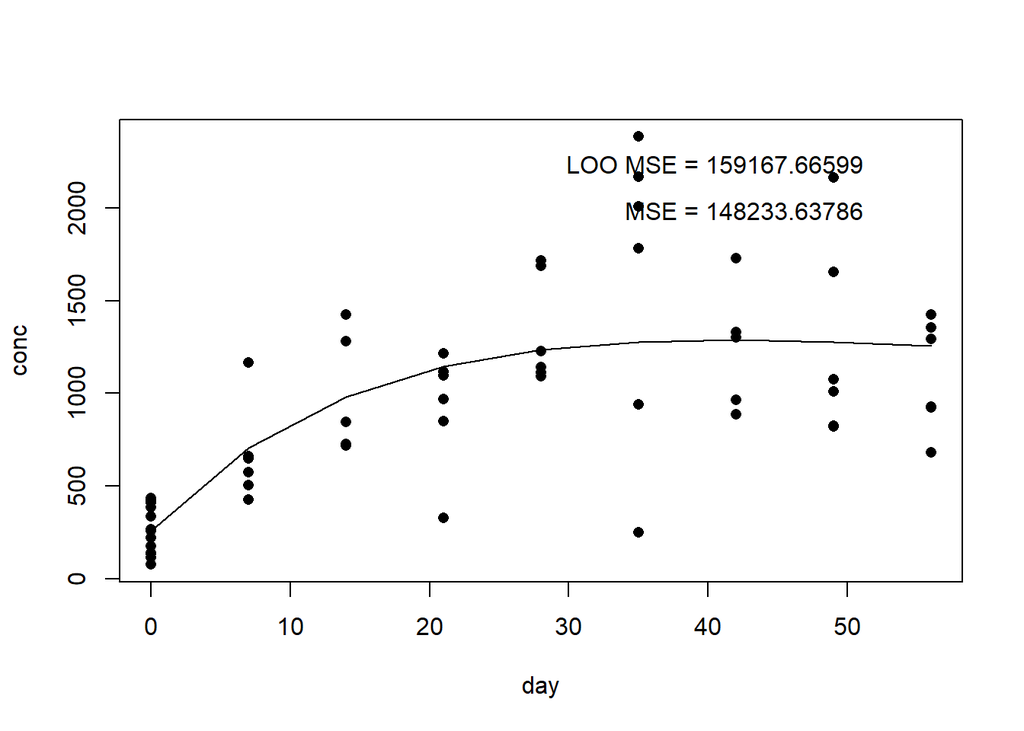

```r
plot(y~x, pch=16, xlab='day', ylab='conc')

d <- nls(y~259.767+((697.138*(3/7)*k01)/(V*(k01-0.007)))*(exp(-0.007*x)-exp(-k01*x)),

           start=list(V=0.1, k01=0.146))

lines(predict(d)[order(x)]~sort(x), lwd=1, col='black')

usr <- par("usr")

text(usr[1] + 0.9*(usr[2]-usr[1]), usr[3] + 0.9*(usr[4]-usr[3]), paste("LOO MSE", "=", round(mean(cvs), 5)), pos=2)

text(usr[1] + 0.9*(usr[2]-usr[1]), usr[3] + 0.8*(usr[4]-usr[3]), paste("MSE", "=", round(mean(resid(d)^2), 5)), pos=2)
```

```r
(148233-159167)/148233
```

```
## [1] -0.07376225
```

```r
#7% impact on prediction

sqrt(sum(cvs)/n) # standard deviation of predicted errors
```

```
## [1] 398.9582
```

```r
#1-(sum(cvs)/sum((y-mean(y))^2)) #predicted R^2 DOES NOT MAKE SENSE FOR NONLINEAR MODELS! IGNORE!

sd(resid(d))
```

```
## [1] 388.2879
```

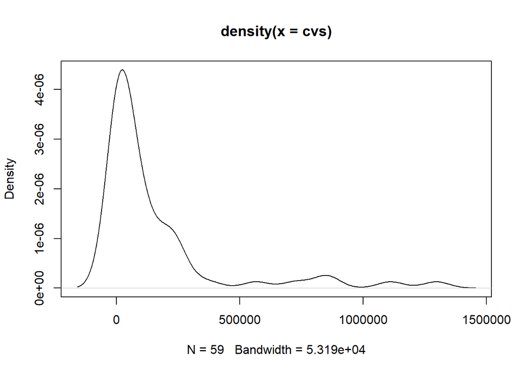

```r
#summary(d)



plot(density(cvs))
```

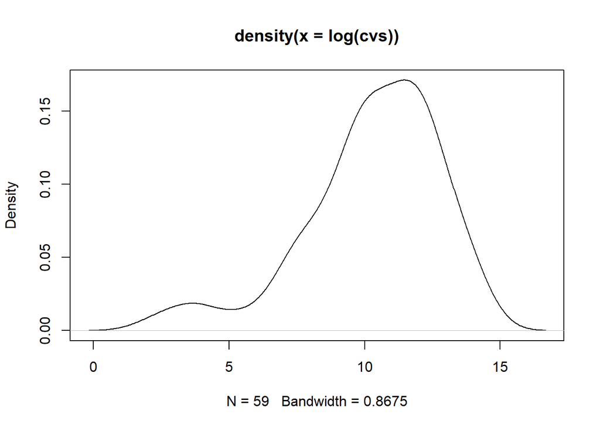

```r
plot(density(log(cvs)))
```

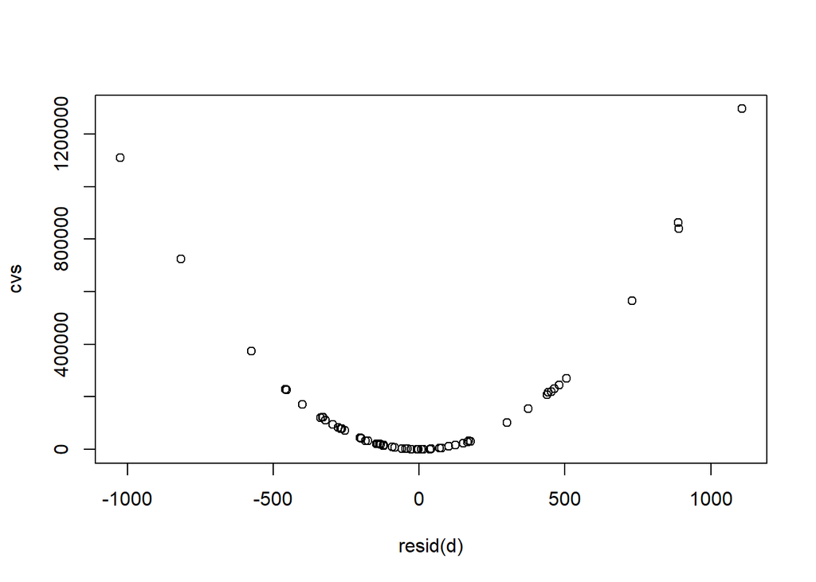

```r
cvsnls <- cvs



plot(cvs~(resid(d)^2))

plot(cvs~resid(d))
```

```r
mean(((resid(d)^2)-cvs)/(resid(d)^2), na.rm=T)
```

```
## [1] -0.0662936
```

```r
mean(((resid(d))-cvs)/(resid(d)), na.rm=T)
```

```
## [1] 7.814561
```

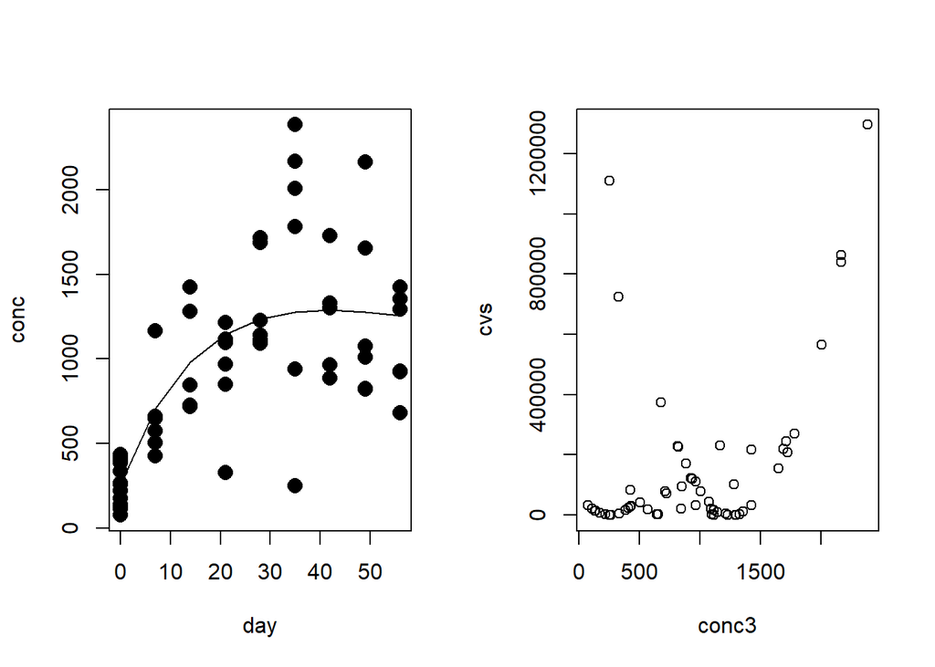

```r
subdata$cvs <- cvs



#plot(cvs~conc3, data=subdata, log="")

#plot(cvs~conc3, data=subdata, log="xy")





par(mfrow=c(1,2))

plot(y~x, pch=16, cex=1.5, xlab='day', ylab='conc')

lines(predict(d)[order(x)]~sort(x), lwd=1, col='black')

plot(cvs~conc3, data=subdata, log="")
```

```r
par(mfrow=c(1,1))
```

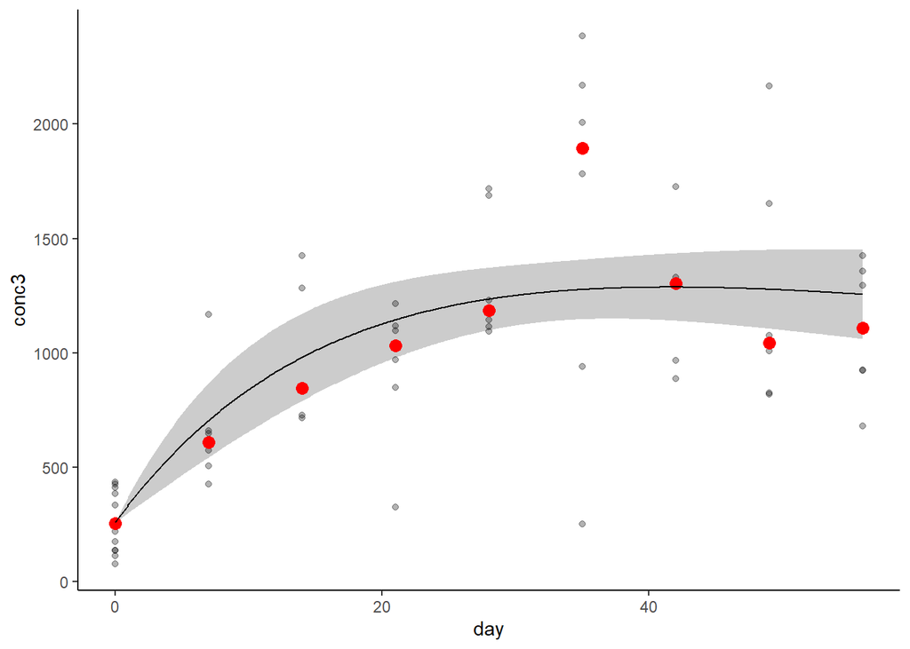

```r
#ggplot() +

#  geom_ribbon(data=nlsplpred,aes(x=day,ymin=fit.lwr,ymax=fit.upr),alpha=0.25) +

#  geom_point(data=toadsumm3%>%filter(tissue=="Liver"&PFAS=="PFOS"&day%in%c(0:56)),aes(x=day,y=median),

#             size=2,alpha=0.3) +

#  geom_line(data=nlsplpred,aes(x=day,y=fit.fit)) +

#  theme_classic()





ggplot() +

  geom_ribbon(data=nlsplpred,aes(x=day,ymin=fit.lwr,ymax=fit.upr),alpha=0.25) +

  geom_point(data=toad%>%filter(tissue=="Liver"&PFAS=="PFOS"&day%in%c(0:56)),aes(x=day,y=conc3),

             size=1.5,alpha=0.3) +

  geom_point(data=toadsumm3%>%filter(tissue=="Liver"&PFAS=="PFOS"&day%in%c(0:56)),aes(x=day,y=median),

             size=3, color="red") +

  geom_line(data=nlsplpred,aes(x=day,y=fit.fit)) +

  theme_classic()
```

#### 8:2 FTS liver via `nls()`

```r
nls8l <- nls(conc3~0.1+((885.228*(3/7)*k01)/(V*(k01-0.108)))*(exp(-0.108*day)-exp(-k01*day)),     #885.228

               data=toad%>%filter(PFAS=="8:2 FTS"&tissue=="Liver"&day%in%c(0:56)),

               start=list(V=0.1, k01=0.83) #,trace=T

             )

summary(nls8l)
```

```
##
## Formula: conc3 ~ 0.1 + ((885.228 * (3/7) * k01)/(V * (k01 - 0.108))) *
##     (exp(-0.108 * day) - exp(-k01 * day))
##
## Parameters:
##     Estimate Std. Error t value Pr(>|t|)
## V    0.99683    0.07512  13.270  < 2e-16 ***
## k01  0.05304    0.00733   7.237 1.28e-09 ***
## ---
## Signif. codes:  0 '***' 0.001 '**' 0.01 '*' 0.05 '.' 0.1 ' ' 1
##
## Residual standard error: 24.42 on 57 degrees of freedom
##
## Number of iterations to convergence: 11
## Achieved convergence tolerance: 9.195e-06
```

```r
nls8lpred <- data.frame(predFit(nls8l, newdata=data.frame(day=seq(from=0, to=56, by=0.1)), interval="confidence", se.fit=T, type="response"))

nls8lpred$day <- c(seq(from=0,to=56,by=0.1))
```

##### LOOCV

```r
subdata <- toad%>%filter(PFAS=="8:2 FTS"&tissue=="Liver"&day%in%c(0:56))



y <- subdata$conc3

x <- subdata$day

n <- length(x)



cvs <- rep(0,n)



for(j in seq(n)){

  ys <- y[-j]

  xs <- x[-j]

  d <- nls(ys~0.1+((885.228*(3/7)*k01)/(V*(k01-0.108)))*(exp(-0.108*xs)-exp(-k01*xs)),

           start=list(V=2, k01=0.05), control=list(maxiter=500))

  cvs[j] <- (y[j]-predict(d,data.frame(xs=x[j])))^2

  print(paste0(j," of ",n," finished (",round(j/n*100),"%)"))

}
```

```
## [1] "1 of 59 finished (2%)"
## [1] "2 of 59 finished (3%)"
## [1] "3 of 59 finished (5%)"
## [1] "4 of 59 finished (7%)"
## [1] "5 of 59 finished (8%)"
## [1] "6 of 59 finished (10%)"
## [1] "7 of 59 finished (12%)"
## [1] "8 of 59 finished (14%)"
## [1] "9 of 59 finished (15%)"
## [1] "10 of 59 finished (17%)"
## [1] "11 of 59 finished (19%)"
## [1] "12 of 59 finished (20%)"
## [1] "13 of 59 finished (22%)"
## [1] "14 of 59 finished (24%)"
## [1] "15 of 59 finished (25%)"
```

[output cut: 44 more lines]

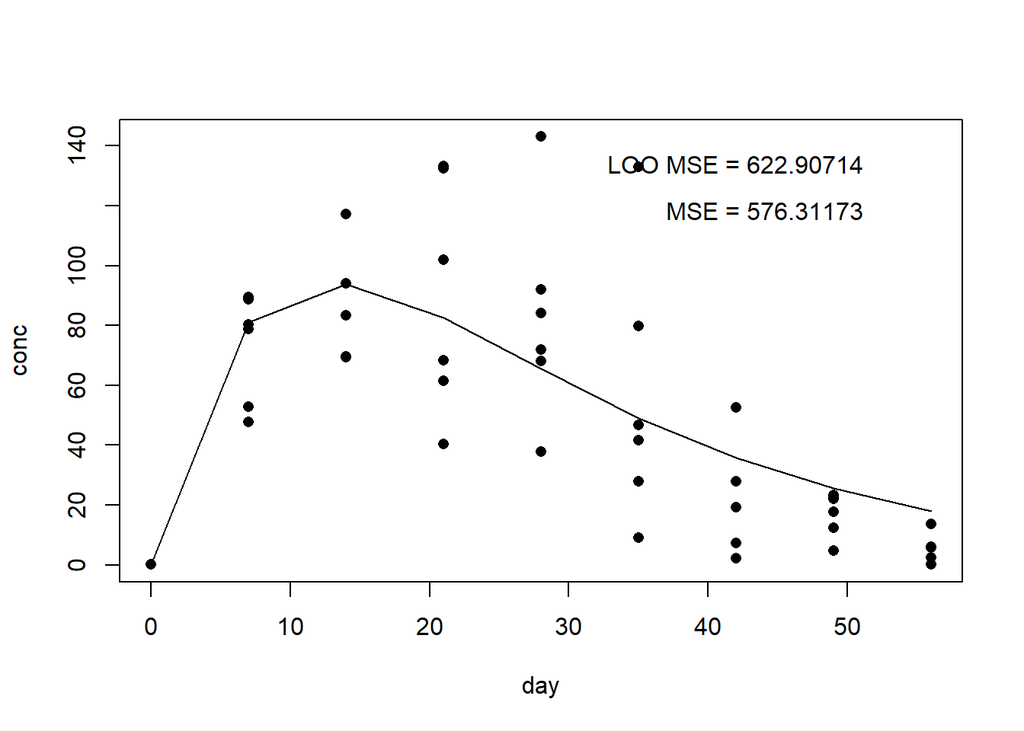

```r
plot(y~x, pch=16, xlab='day', ylab='conc')

d <- nls(y~0.1+((885.228*(3/7)*k01)/(V*(k01-0.108)))*(exp(-0.108*x)-exp(-k01*x)),

           start=list(V=2, k01=0.05))

lines(predict(d)[order(x)]~sort(x), lwd=1, col='black')

usr <- par("usr")

text(usr[1] + 0.9*(usr[2]-usr[1]), usr[3] + 0.9*(usr[4]-usr[3]), paste("LOO MSE", "=", round(mean(cvs), 5)), pos=2)

text(usr[1] + 0.9*(usr[2]-usr[1]), usr[3] + 0.8*(usr[4]-usr[3]), paste("MSE", "=", round(mean(resid(d)^2), 5)), pos=2)
```

```r
(576.31-622.91)/576.31
```

```
## [1] -0.08085926
```

```r
#8% impact on prediction

sqrt(sum(cvs)/n) # standard deviation of predicted errors
```

```
## [1] 24.95811
```

```r
#1-(sum(cvs)/sum((y-mean(y))^2)) #predicted R^2 DOES NOT MAKE SENSE FOR NONLINEAR MODELS! IGNORE!

sd(resid(d))
```

```
## [1] 24.16408
```

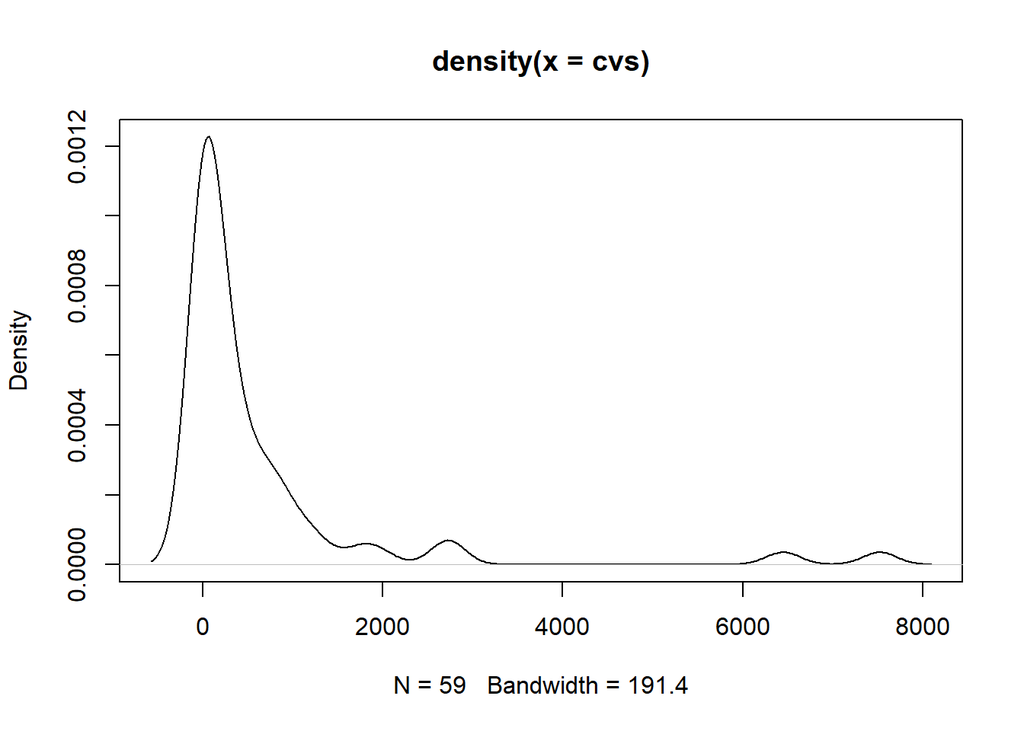

```r
#summary(d)



plot(density(cvs))
```

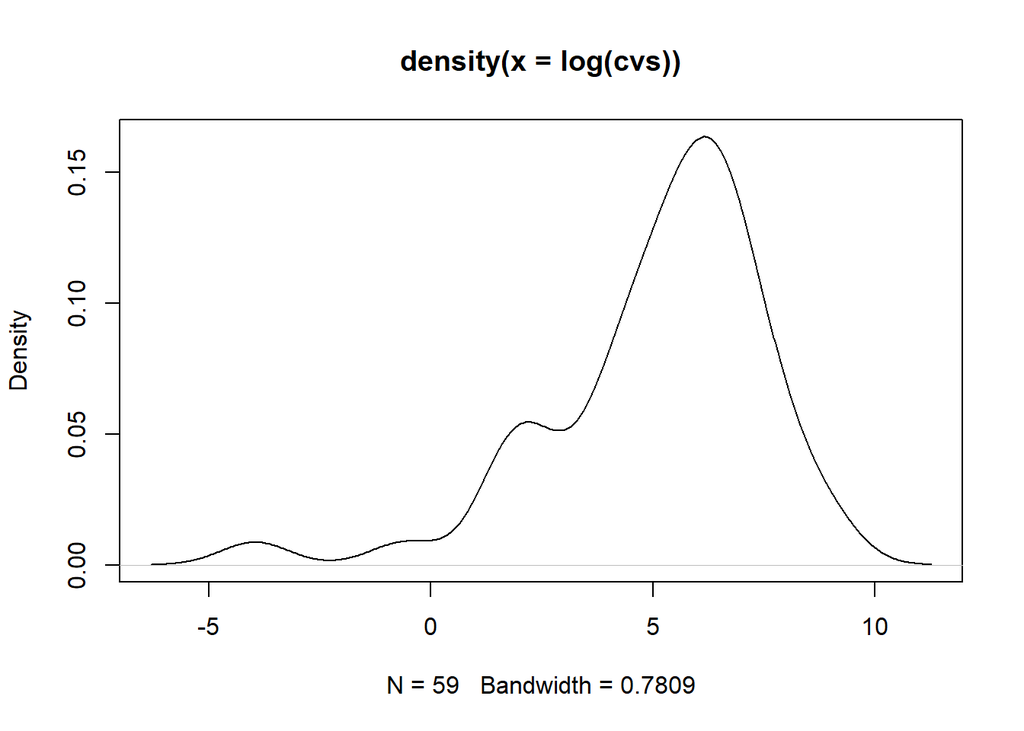

```r
plot(density(log(cvs)))
```

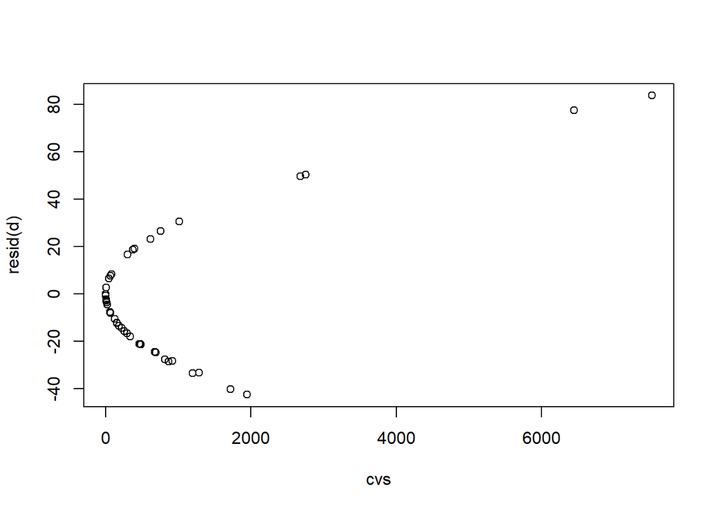

```r
plot(resid(d)~cvs)
```

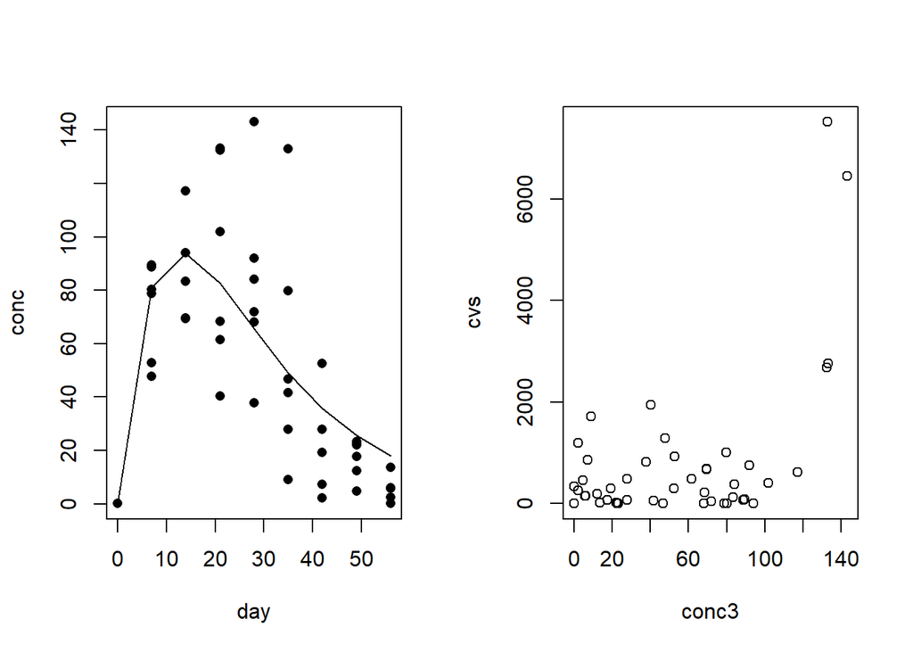

```r
subdata$cvs <- cvs



#plot(cvs~conc3, data=subdata, log="")

#plot(cvs~conc3, data=subdata, log="xy")





par(mfrow=c(1,2))

plot(y~x, pch=16, xlab='day', ylab='conc', log="")

lines(predict(d)[order(x)]~sort(x), lwd=1, col='black')

plot(cvs~conc3, data=subdata, log="")
```

```r
par(mfrow=c(1,1))
```

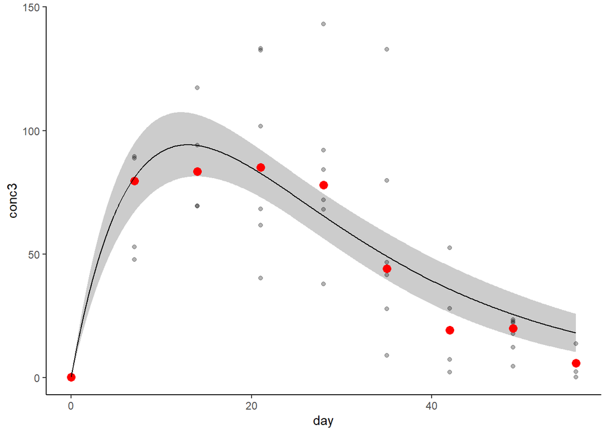

```r
#ggplot() +

#  geom_ribbon(data=nlsplpred,aes(x=day,ymin=fit.lwr,ymax=fit.upr),alpha=0.25) +

#  geom_point(data=toadsumm3%>%filter(tissue=="Liver"&PFAS=="PFOS"&day%in%c(0:56)),aes(x=day,y=median),

#             size=2,alpha=0.3) +

#  geom_line(data=nlsplpred,aes(x=day,y=fit.fit)) +

#  theme_classic()





ggplot() +

  geom_ribbon(data=nls8lpred,aes(x=day,ymin=fit.lwr,ymax=fit.upr),alpha=0.25) +

  geom_point(data=toad%>%filter(tissue=="Liver"&PFAS=="8:2 FTS"&day%in%c(0:56)),aes(x=day,y=conc3),

             size=1.5,alpha=0.3) +

  geom_point(data=toadsumm3%>%filter(tissue=="Liver"&PFAS=="8:2 FTS"&day%in%c(0:56)),aes(x=day,y=median),

             size=3, color="red") +

  geom_line(data=nls8lpred,aes(x=day,y=fit.fit)) +

  theme_classic()
```

#### PFOS Whole Body via `nls()`

```r
nlspw <- nls(conc3~26.568+((697.138*(3/7)*k01)/(V*(k01-0.007)))*(exp(-0.007*day)-exp(-k01*day)),

               data=toad%>%filter(PFAS=="PFOS"&tissue=="Whole Body"&day%in%c(0:56)),

               start=list(V=0.1, k01=0.265) #,trace=T

             )

summary(nlspw)
```

```
##
## Formula: conc3 ~ 26.568 + ((697.138 * (3/7) * k01)/(V * (k01 - 0.007))) *
##     (exp(-0.007 * day) - exp(-k01 * day))
##
## Parameters:
##     Estimate Std. Error t value Pr(>|t|)
## V    0.61323    0.08864   6.918 4.35e-09 ***
## k01  0.05936    0.02504   2.370   0.0212 *
## ---
## Signif. codes:  0 '***' 0.001 '**' 0.01 '*' 0.05 '.' 0.1 ' ' 1
##
## Residual standard error: 182.1 on 57 degrees of freedom
##
## Number of iterations to convergence: 7
## Achieved convergence tolerance: 1.562e-06
```

```r
nlspwpred <- data.frame(predFit(nlspw, newdata=data.frame(day=seq(from=0, to=56, by=0.1)), interval="confidence", se.fit=T, type="response"))

nlspwpred$day <- c(seq(from=0,to=56,by=0.1))
```

##### LOOCV

```r
subdata <- toad%>%filter(PFAS=="PFOS"&tissue=="Whole Body"&day%in%c(0:56))



y <- subdata$conc3

x <- subdata$day

n <- length(x)



cvs <- rep(0,n)



for(j in seq(n)){

  ys <- y[-j]

  xs <- x[-j]

  d <- nls(ys~26.568+((697.138*(3/7)*k01)/(V*(k01-0.007)))*(exp(-0.007*xs)-exp(-k01*xs)),

           start=list(V=0.1, k01=0.265))

  cvs[j] <- (y[j]-predict(d,data.frame(xs=x[j])))^2

  print(paste0(j," of ",n," finished (",round(j/n*100),"%)"))

}
```

```
## [1] "1 of 59 finished (2%)"
## [1] "2 of 59 finished (3%)"
## [1] "3 of 59 finished (5%)"
## [1] "4 of 59 finished (7%)"
## [1] "5 of 59 finished (8%)"
## [1] "6 of 59 finished (10%)"
## [1] "7 of 59 finished (12%)"
## [1] "8 of 59 finished (14%)"
## [1] "9 of 59 finished (15%)"
## [1] "10 of 59 finished (17%)"
## [1] "11 of 59 finished (19%)"
## [1] "12 of 59 finished (20%)"
## [1] "13 of 59 finished (22%)"
## [1] "14 of 59 finished (24%)"
## [1] "15 of 59 finished (25%)"
```

[output cut: 44 more lines]

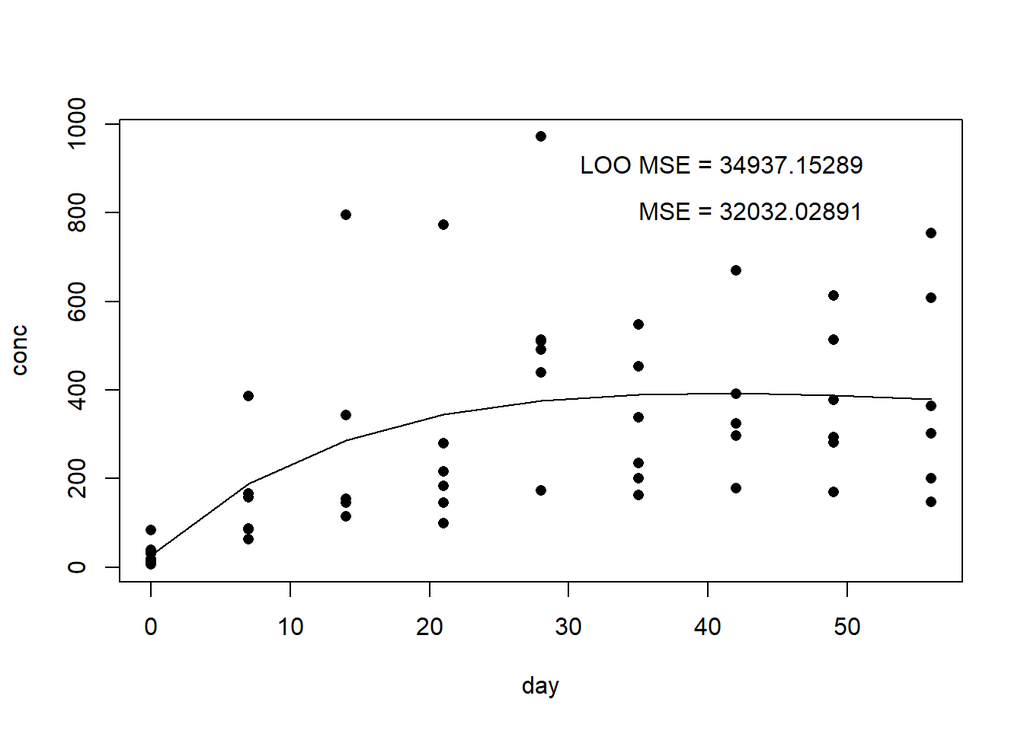

```r
plot(y~x, pch=16, xlab='day', ylab='conc')

d <- nls(y~26.568+((697.138*(3/7)*k01)/(V*(k01-0.007)))*(exp(-0.007*x)-exp(-k01*x)),

           start=list(V=0.1, k01=0.265))

lines(predict(d)[order(x)]~sort(x), lwd=1, col='black')

usr <- par("usr")

text(usr[1] + 0.9*(usr[2]-usr[1]), usr[3] + 0.9*(usr[4]-usr[3]), paste("LOO MSE", "=", round(mean(cvs), 5)), pos=2)

text(usr[1] + 0.9*(usr[2]-usr[1]), usr[3] + 0.8*(usr[4]-usr[3]), paste("MSE", "=", round(mean(resid(d)^2), 5)), pos=2)
```

```r
(32032.03-34937.14)/32032.03
```

```
## [1] -0.09069391
```

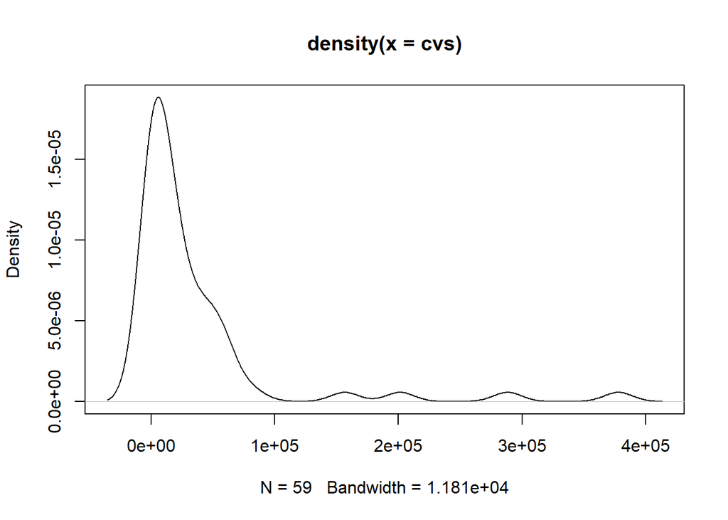

```r
#9% impact on prediction



plot(density(cvs))
```

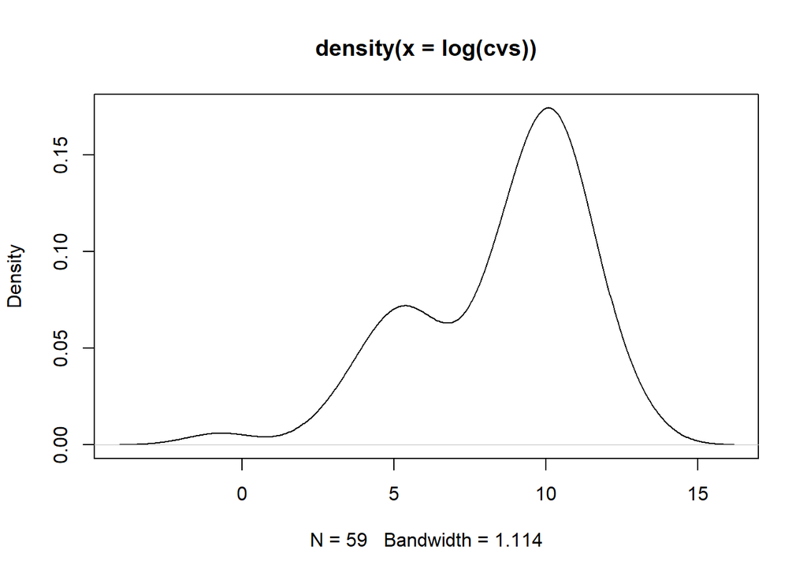

```r
plot(density(log(cvs)))
```

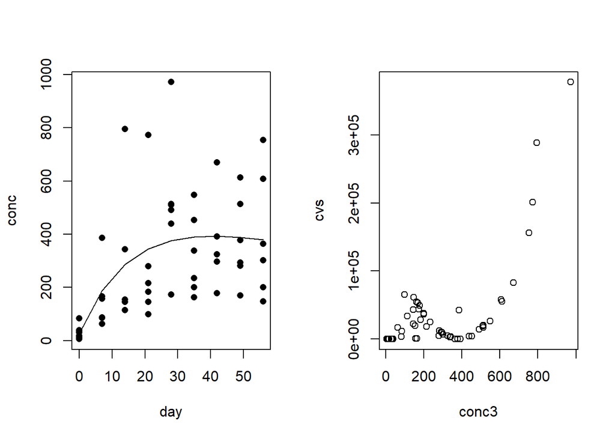

```r
subdata$cvs <- cvs



#plot(cvs~conc3, data=subdata, log="")

#plot(cvs~conc3, data=subdata, log="xy")





par(mfrow=c(1,2))

plot(y~x, pch=16, xlab='day', ylab='conc')

lines(predict(d)[order(x)]~sort(x), lwd=1, col='black')

plot(cvs~conc3, data=subdata, log="")
```

```r
par(mfrow=c(1,1))
```

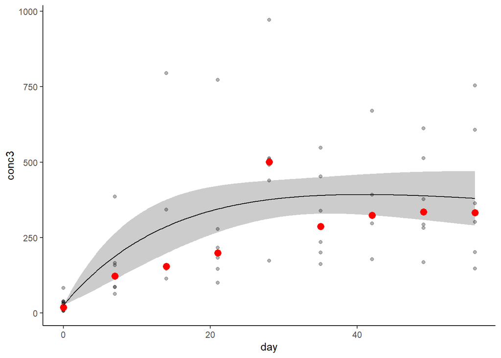

```r
#ggplot() +

#  geom_ribbon(data=nlsplpred,aes(x=day,ymin=fit.lwr,ymax=fit.upr),alpha=0.25) +

#  geom_point(data=toadsumm3%>%filter(tissue=="Liver"&PFAS=="PFOS"&day%in%c(0:56)),aes(x=day,y=median),

#             size=2,alpha=0.3) +

#  geom_line(data=nlsplpred,aes(x=day,y=fit.fit)) +

#  theme_classic()





ggplot() +

  geom_ribbon(data=nlspwpred,aes(x=day,ymin=fit.lwr,ymax=fit.upr),alpha=0.25) +

  geom_point(data=toad%>%filter(tissue=="Whole Body"&PFAS=="PFOS"&day%in%c(0:56)),aes(x=day,y=conc3),

             size=1.5,alpha=0.3) +

  geom_point(data=toadsumm3%>%filter(tissue=="Whole Body"&PFAS=="PFOS"&day%in%c(0:56)),aes(x=day,y=median),

             size=3, color="red") +

  geom_line(data=nlspwpred,aes(x=day,y=fit.fit)) +

  theme_classic()
```

#### 8:2 FTS Whole Body via `nls()`

```r
nls8l <- nls(conc3~0.1+((885.228*(3/7)*k01)/(V*(k01-0.091)))*(exp(-0.091*day)-exp(-k01*day)),

               data=toad%>%filter(PFAS=="8:2 FTS"&tissue=="Whole Body"&day%in%c(0:56)),

               start=list(V=0.1, k01=0.828) #,trace=T

             )

summary(nls8l)
```

```
##
## Formula: conc3 ~ 0.1 + ((885.228 * (3/7) * k01)/(V * (k01 - 0.091))) *
##     (exp(-0.091 * day) - exp(-k01 * day))
##
## Parameters:
##     Estimate Std. Error t value Pr(>|t|)
## V    2.32370    0.30449   7.631 2.82e-10 ***
## k01  0.06352    0.01612   3.941 0.000224 ***
## ---
## Signif. codes:  0 '***' 0.001 '**' 0.01 '*' 0.05 '.' 0.1 ' ' 1
##
## Residual standard error: 23.47 on 57 degrees of freedom
##
## Number of iterations to convergence: 10
## Achieved convergence tolerance: 2.086e-06
```

```r
nls8lpred <- data.frame(predFit(nls8l, newdata=data.frame(day=seq(from=0, to=56, by=0.1)), interval="confidence", se.fit=T, type="response"))

nls8lpred$day <- c(seq(from=0,to=56,by=0.1))
```

##### LOOCV

```r
subdata <- toad%>%filter(PFAS=="8:2 FTS"&tissue=="Whole Body"&day%in%c(0:56))



y <- subdata$conc3

x <- subdata$day

n <- length(x)



cvs <- rep(0,n)



for(j in seq(n)){

  ys <- y[-j]

  xs <- x[-j]

  d <- nls(ys~0.1+((885.228*(3/7)*k01)/(V*(k01-0.091)))*(exp(-0.091*xs)-exp(-k01*xs)),

           start=list(V=0.1, k01=0.828))

  cvs[j] <- (y[j]-predict(d,data.frame(xs=x[j])))^2

  print(paste0(j," of ",n," finished (",round(j/n*100),"%)"))

}
```

```
## [1] "1 of 59 finished (2%)"
## [1] "2 of 59 finished (3%)"
## [1] "3 of 59 finished (5%)"
## [1] "4 of 59 finished (7%)"
## [1] "5 of 59 finished (8%)"
## [1] "6 of 59 finished (10%)"
## [1] "7 of 59 finished (12%)"
## [1] "8 of 59 finished (14%)"
## [1] "9 of 59 finished (15%)"
## [1] "10 of 59 finished (17%)"
## [1] "11 of 59 finished (19%)"
## [1] "12 of 59 finished (20%)"
## [1] "13 of 59 finished (22%)"
## [1] "14 of 59 finished (24%)"
## [1] "15 of 59 finished (25%)"
```

[output cut: 44 more lines]

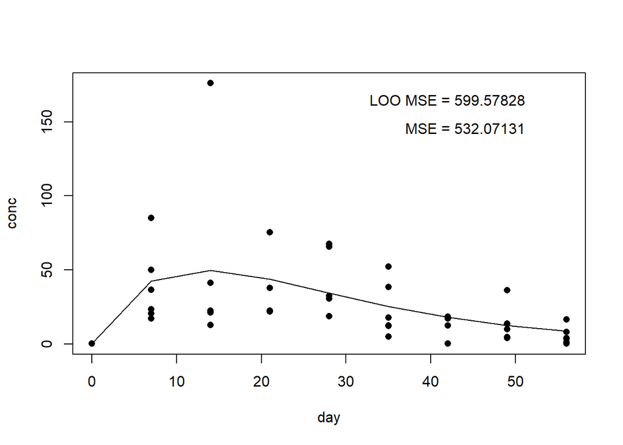

```r
plot(y~x, pch=16, xlab='day', ylab='conc')

d <- nls(y~0.1+((885.228*(3/7)*k01)/(V*(k01-0.091)))*(exp(-0.091*x)-exp(-k01*x)),

           start=list(V=0.1, k01=0.828))

lines(predict(d)[order(x)]~sort(x), lwd=1, col='black')

usr <- par("usr")

text(usr[1] + 0.9*(usr[2]-usr[1]), usr[3] + 0.9*(usr[4]-usr[3]), paste("LOO MSE", "=", round(mean(cvs), 5)), pos=2)

text(usr[1] + 0.9*(usr[2]-usr[1]), usr[3] + 0.8*(usr[4]-usr[3]), paste("MSE", "=", round(mean(resid(d)^2), 5)), pos=2)
```

```r
(532.07-599.58)/532.07
```

```
## [1] -0.1268818
```

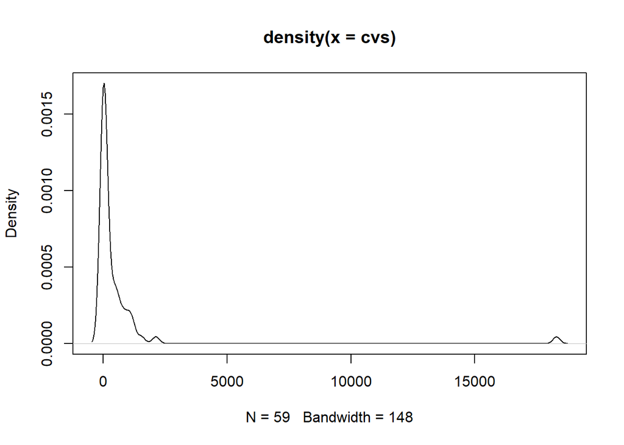

```r
#12.7% impact on prediction



plot(density(cvs))
```